# Building a Dynamic TOPMODEL

The purpose of this vignette is to provide an outline of the steps needed to build a dynamic TOPMODEL implementation using the dynatopGIS package.

# Implementation notes

The dynatopGIS package implements a structured, object orientated, data flow. The steps outlined below create a `dynatopGIS` catchment object to which actions are then applied to generate a model.

The `dynatopGIS` package is written using the object orientated framework provided by the `R6` package. This means that some aspects of working with the objects may appear idiosyncratic for some R users. In using the package as outlined in this vignette these problems are largely obscured, except for the call structure. However, before adapting the code, or doing more complex analysis users should read about `R6` class objects (e.g. in the `R6` package vignettes or in the Advanced R book). One particular gotcha is when copying an object. Using

```r
my_new_object  <-  my_object
```

creates a pointer, that is altering `my_new_object` also alters `my_object`. To create a new independent copy of `my_object` use

```r
my_new_object  <-  my_object$clone()
```

# Getting started

The dynatopGIS packages works through a number of steps to generate a Dynamic TOPMODEL object suitable for use in with the `dynatop` package. Each step generates one or more layers which are saved as raster or shape files into the projects working directory (which is not necessarily the R working directory). A record of these layers is kept in the json format meta data file.

This vignette demonstrates the use of the `dynatopGIS` package using data from the Swindale catchment in the UK.

To start first load the library

```r
library("dynatopGIS")
```

For this vignette we will store the data into a temporary directory

```r
demo_dir <- tempfile("dygis")
dir.create(demo_dir)
```

and initialise the analysis by creating a new object specifying the location of the meta data file, which will be created if it doesn’t exist.

```r
ctch <- dynatopGIS$new(file.path(demo_dir,"meta.json"))
```

# Adding catchment data

The basis of the analysis is a rasterised Digital Elevation Model (DEM) of the catchment and a vectorised representation of the river network with attributes. Currently these can be in any format supported by the `raster` and `sp` libraries respectively.

However, within the calculations used for sink filling, flow routing and topographic index calculations the raster DEM is presumed to be projected so that is has square cells such that the difference between the cell centres (in meters) does not alter.

For Swindale the suitable DEM and channel files can be found using:

```r
dem_file <- system.file("extdata", "SwindaleDTM40m.tif", package="dynatopGIS", mustWork = TRUE)
channel_file <- system.file("extdata", "SwindaleRiverNetwork.shp", package="dynatopGIS", mustWork = TRUE)
```

Either the DEM or channel files can be added to the project first. In this case we add the DEM with

```r
dem <- terra::rast(dem_file)
ctch$add_dem(dem)
```

*Note:* An additional row and column of `NA` is added to each edge of the DEM. All raster layers in the project have the same projection, resolution and extent of the extended DEM.

Additional properties are currently kept but ignored with two exceptions: - *id* - this is copied to `original_id` with a warning since `id` is used internally - *width* - if the channel is specified with a line sections then the *width* property is used to buffer the lines to create channel polygons.

Since it is possible that these properties are present in a data file under different names the `add_channel` method allows for renaming. To illustrate this let us examine the river network for Swindale

```r
sp_lines <- terra::vect(channel_file)
```

```
#> Warning: [vect] Z coordinates ignored
```

```r
head(sp_lines)
```

```
#>  class       : SpatVector
#>  geometry    : lines
#>  dimensions  : 6, 11  (geometries, attributes)
#>  extent      : 349884.5, 351675.7, 508614.5, 513074.7  (xmin, xmax, ymin, ymax)
#>  coord. ref. : OSGB36 / British National Grid (EPSG:27700)
#>  names       :           name1      identifier       startNode         endNode
#>  type        :           <chr>           <chr>           <chr>           <chr>
#>  values      :   Hawthorn Gill 16D0AC09-E0B6-~ 730F01D2-0F4F-~ 72B1A40B-E106-~
#>                Little Mosedal~ 643017BB-01BC-~ 9B06188C-F4C7-~ A19E0D3A-2FA1-~
#>                  Mosedale Beck D2C2703E-A32F-~ B03DB3BD-0E33-~ D649B60C-E631-~
#>         form         flow fictitious length name2 sinkdepth Shape_Leng
#>        <chr>        <chr>      <chr>  <int> <chr>     <num>      <num>
#>  inlandRiver in direction      false    431    NA        -1      431.3
#>  inlandRiver in direction      false    513    NA        -1      513.1
#>  inlandRiver in direction      false    740    NA        -1      739.8
```

The main properties are present under appropriate names and a call to the `add_channel` method with no options would be successful. However if we want to carry over the additional information in the “identifier” as “channel_id” a named vector giving the variable names to be used could be provided. In this case:

```r
property_names <- c(channel_id="identifier",
                    endNode="endNode",
                    startNode="startNode",
                    length="length")
```

The river network can then be created in the correct format by

```r
ctch$add_channel(sp_lines,property_names)
```

Since the data set for Swindale does not contain a channel width the default width of 2m is used.

# Computing Basic Properties

So far, the DEM and channel data exist in isolation. Next, we compute some basic summaries for each square in the DEM, specifically: - land area - the area in the DEM cell covered by land - channel area - the area in the DEM cell covered by channel - channel id - the id of the channel within the cell, corresponding to the id in the channel object.

If multiple river lengths intersect a DEM cell the properties of the channel length with the largest area of intersection are used.

This computation is done by calling

```r
ctch$compute_areas()
```

# Getting and plotting catchment information

The `dynatopGIS` class has methods for returning and plotting the GIS data in the project. The names of all the different GIS layers stored is returned by

```r
ctch$get_layer()
```

```
#> [1] "dem"          "channel"      "land_area"    "channel_area" "channel_id"
```

These can be plotted (with or without the channel), for example

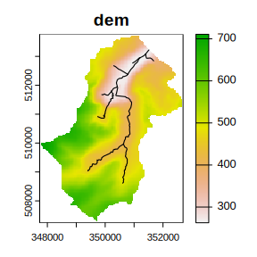

```r
ctch$plot_layer("dem", add_channel=TRUE)
```

or returned, for example

```r
ctch$get_layer("dem")
```

```
#> class       : SpatRaster
#> dimensions  : 163, 124, 1  (nrow, ncol, nlyr)
#> resolution  : 40, 40  (x, y)
#> extent      : 347734, 352694, 507244, 513764  (xmin, xmax, ymin, ymax)
#> coord. ref. : +proj=tmerc +lat_0=49 +lon_0=-2 +k=0.9996012717 +x_0=400000 +y_0=-100000 +ellps=airy +units=m +no_defs
#> source      : dem.tif
#> name        : SwindaleDTM40m
#> min value   :       262.8004
#> max value   :       710.7533
```

```r
tmp <- ctch$get_meta()
```

# Filling sinks

For the hill slope to be connected to the river network all DEM cells must drain to those that intersect with the river network.

The algorithm of implemented in the `sink_fill` method ensures this is the case. Since the algorithm is iterative the execution time of the function is limited by capping the maximum number of iterations. If this limit is reached without completion the method can call again with the “hot start” option to continue from where it finished.

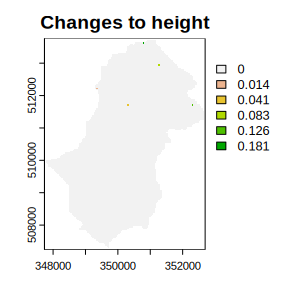

```r
ctch$sink_fill()

terra::plot( ctch$get_layer('filled_dem') - ctch$get_layer('dem'),
             main="Changes to height")
```

# Computing properties

Two sets of properties are required for Dynamic TOPMODEL. The first set is those required within the evaluation of the model; gradient and contour length. The second set are those used for dividing the catchment up into Hydrological Response Units (HRUs). Traditionally the summary used for the separation of the HRUs is the topographic index, which is the natural logarithm of the upslope area divided by gradient.

These are computed using the formulae in [Quinn et al. 1991](https://doi.org/10.1002/hyp.3360050106).

The upstream area is computed by routing down slope with the fraction of the area being routed to the next downstream pixel being proportional to the gradient times the contour length.

The local value of the gradient is computed using the average of a subset of between pixel gradients. For a normal ‘hill slope’ cell these are the gradients to downslope pixels weighted by contour length. In the case of pixels which contain river channels the average of the gradients from upslope pixels weighted by contour length us used.

These properties are computed in an algorithm that passes over the data once in descending height. It is called as follows

```r
ctch$compute_properties()
```

The plot of the topographic index shows a pattern of increasing values closer to the river channels

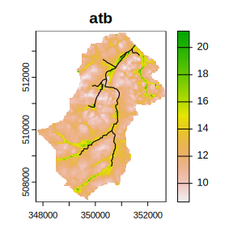

```r
## plot of topographic index (log(a/tan b))
ctch$plot_layer('atb')
```

## Adding additional layer

Properties may come in additional GIS layers. To demonstrate the addition of an additional layer we will extract the filled dem

```r
tmp <- ctch$get_layer("filled_dem")
```

then separate it into a layers representing land above and below 500m.

```r
tmp <- terra::classify( tmp,
                       matrix(c(0,500,NA,
                                500,1000,-999),
                              ncol=3, byrow=TRUE))
```

The resulting raster object can now be written to a file

```r
terra::writeRaster(tmp,file.path(demo_dir,"greater_500.tif"))
```

which is added to the meta data with

```r
ctch$add_layer("greater_500",file.path(demo_dir,"greater_500.tif"))
ctch$get_layer()
```

```
#>  [1] "dem"          "channel"      "filled_dem"   "land_area"    "channel_area"
#>  [6] "channel_id"   "gradient"     "upslope_area" "atb"          "greater_500"
```

# Flow distances and ordering

Since `dynatop` simulations make use of ordered HRUs to work downslope, a metric is required to order the downslope sequencing. The calculation of four such metrics is supported

- *shortest flow length* - the shortest length based on the pixel flow paths to a channel
- *Dominant flow length* - the distance to a channel moving in the dominant (largest fraction) flow direction from any grid cell
- *Expected flow length* - the distance to the channel based on a weighted average of the downslope flow lengths. Weights are given by the fraction of flow in each direction.
- *Band* - A strict computational order, starting at the channel arranged such that if all pixels in band $i+1,i+2,\ldots$ are evaluated the inflows to band $i$ are known.

The computation is initiated with

```r
ctch$compute_flow_lengths()
```

The additional layers can be examined as expected

```r
ctch$get_layer()
```

```
#>  [1] "dem"                  "channel"              "filled_dem"
#>  [4] "land_area"            "channel_area"         "channel_id"
#>  [7] "gradient"             "upslope_area"         "atb"
#> [10] "band"                 "shortest_flow_length" "dominant_flow_length"
#> [13] "expected_flow_length" "greater_500"
```

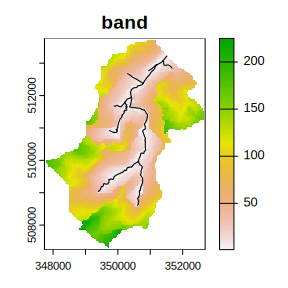

```r
ctch$plot_layer("band")
```

# Classifying into Hydrological Response Units

Methods are provided for the classification of the catchment areas of similar hydrological response. The classifications generated in this process are augmented with a further distance based separation when generating a `dynatop` model (see following section).

By definition each channel length is treated as belonging to a single class.

To classify the hillslope two methods can be used.

The `classify` method of a `dynatopGIS` allows a landscape property to be *cut* into classes.

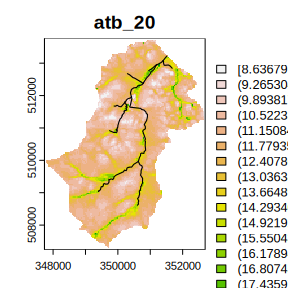

```r
ctch$classify("atb_20","atb",cuts=20)
ctch$plot_layer("atb_20")
```

Providing a single value to the cuts argument determines the number of classes. The values used to cut the variable can be extracted from the meta data with

```r
ctch$get_class_method("atb_20")
```

```
#> $layer
#> [1] "atb"
#>
#> $cuts
#>  [1]  8.636791  9.265304  9.893817 10.522330 11.150843 11.779356 12.407868
#>  [8] 13.036381 13.664894 14.293407 14.921920 15.550433 16.178946 16.807458
#> [15] 17.435971 18.064484 18.692997 19.321510 19.950023 20.578536 21.207048
```

The `combine_classes` method of a `dynatopGIS` allows classes to be combined in two ways, which are applied in the order shown

- *pairing* - where unique combinations of classes create one new class
- *burning* - where a single class is imposed upon an area

To demonstrate a pairing combination consider combining the atb classes generated above with the classification provided by the distance band

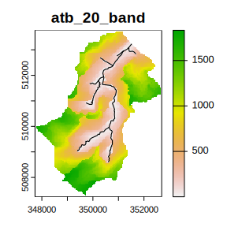

```r
ctch$combine_classes("atb_20_band",c("atb_20","band"))
ctch$plot_layer("atb_20_band")
```

Additionally the land greater then 500 in altitude can be burnt in with

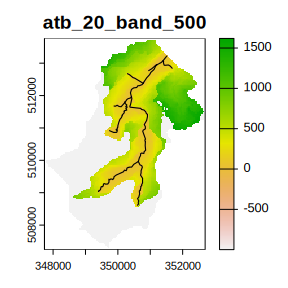

```r
ctch$combine_classes("atb_20_band_500",pairs=c("atb_20","band"),burns="greater_500")
ctch$plot_layer("atb_20_band_500")
```

The each class in the combined classification the values of the classes used in the computations can be returned

```r
head( ctch$get_class_method("atb_20_band_500") )
```

```
#>   atb_20_band_500 atb_20 band greater_500
#> 1               1      1    1          NA
#> 2               2      2    1          NA
#> 3               3      3    1          NA
#> 4               4      4    1          NA
#> 5               5      5    1          NA
#> 6               6      4    2          NA
```

Note that by giving the area to be burnt in a negative value when it was generated above we have ensured that the values do not clash with those generated by the cuts which (except potentially when a cut is NA) will always be positive.

# Generating a dynamic TOPMODEL

A Dynamic TOPMODEL suitable for use with the `dynatop` package can be generated using the `create_model` method. This uses an existing classification to generate the model. The required model structure is given in the vignettes of `dynatop` package and is not described here in details.

Since `dynatop` simulations make use of ordered HRUs to work downslope, a classification which used a distance layer (see earlier section) which represents the ordered downslope sequencing of the pixels is recommended. *It is strongly recommended that the ‘band’ distance metric is used directly as shown below*.

Even if a distance layer is not used in the classification one must be given to the `create_model` method, so the resulting HRUs can be ordered.

```r
ctch$create_model("new_model","atb_20_band","band")
```

```
#> The following Channel HRUs are outflows: 1
```

Looking at the files within the `demo_dir` folder

```r
list.files(demo_dir,pattern="new_model*")
```

```
#> [1] "new_model.rds" "new_model.tif"
```

shows that an addition raster map of the HRUs has been created in `new_model.tif` along with a file `new_model.rds` containing a model suitable for `dynatop`

The map of HRUs can be plotted as with any layer

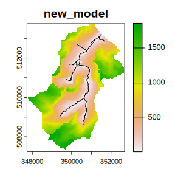

```r
ctch$plot_layer("new_model")
```

The values on the map correspond to the `ìd` column of the hillslope table in the `dynatop` model.